# Final Project

Jiaxuan Wu

Nov 10th, 2022

## Introduction & Background

### Introduction

Bladder cancer stands as the 12th most prevalent cancer in the world with about 25% of sufferers also suffering bone metastatic disease. Bone metastases worsens prognosis for this cancer greatly, with the 5-year survival rate dropping from 69.5% for the disease staying within the bladder to only 4.6% once it has spread to the bone (Stellato 2021). Bone metastases have extremely poor prognoses because they are associated with skeletal related events (SREs). Skeletal-related events include pathologic bone fractures, compression of the spinal cord, surgical orthopedic intervention and radiation to reduce bone pain (So A 2012). Current literature explains that SREs are not greatly understood (Stellato 2021), but their association with worsened patient outcomes and decreased quality of life is why we want to further explore our data set and look into possible predictors of SREs for bladder cancer patients. We are exploring a data set that includes demographic and clinical characteristics for 329 bladder cancer patients to answer the question: What are the predictors of having a Skeletal Related Event (SRE) within 2 months of diagnosis of bone metastases in bladder cancer patients? Understanding predictors of SREs may help health care professionals with long-term disease management and hopefully improve patient outcomes.

### Background

Our dataset includes demographic and clinical features for bladder cancer with bone metastases. We will be looking at these factors against our outcome variable which is the time in months to the first SRE event after the diagnosis of bony metastases. This background section provides some insight on what some of those factors are and why they were variables of interest when looking at possible predictors.

Bladder cancer itself is defined as cancer that forms in the tissues of the bladder. In terms of histology, Urothelial bladder cancer makes up the majority of patients and is defined as cancer originating in the urothelial cells that line the bladder. Other less common histological types of bladder cancer are adenocarcinomas and small cell carcinomas (Chalasani 2009). The progression of bladder cancer at the time of diagnosis is defined by cancer stages in our data set. The stages present in our dataset are: Distant Metastases, Localized UTUC, MIBC, NMIBC and Regional. Distant metastases, as defined by the NIH Seer Training Modules, is defined by cancer cells that have spread to other parts of the body. Localized Upper Tract Urothelial Cancer (UTUC) is when the cancer is limited to the renal pelvis or ureter. Muscle Invasive Bladder Cancer (MIBC) is when the cancer has spread to the muscle of bladder. Non-Muscle Invasive Cancer is when the cancer has not yet spread to the muscle of the bladder (Chen 2019). Lastly, Regional cancer is defined as cancer that has spread to a region around the bladder. Prognosis is generally worse for cancers that have spread outside of a localized area in the bladder (Stellato 2021). Looking at this variable allows us to see if cancer stage is associated with the time of a first SRE event for these patients and if this variable can be looked at as a possible predictor for an SRE.

A common treatment for bladder cancer is a cystectomy which is the full or partial removal of the urinary bladder. Cystectomies can be continent or incontinent in terms of urinary diversion (Cheung 2013).

Another variable explored in the data set are the types of metastasis at diagnosis. This variable gives insight on the types of metastases present for each patient, whether they be osseous (the cancer spreading to the bone), visceral (meaning the cancer spread to visceral organs), or if there was spread to local or distant lymph nodes. Looking at the locations of spread for the disease may help us see if this can be used as a possible predictor for an SRE.

Locations for where bone metastases had occurred for each patient was also present in the dataset. Specifically, metastasis occurring in the vertebrae, pelvis, hip, non-vertebral chest, the bones of an extremity and the skull were examined. Once again, looking at the locations of disease spreading may help us see if this can be used as a possible predictor for an SRE.

## Methods

This is an observational study designed to find the potential predictors of skeletal-related event (SRE) among Bladder Cancer Patients with Bone Metastases. The associations between age at diagnosis of bladder cancer, did the patient have the symptoms at diagnosis of bone metastasis, and type of urinary diversion with SRE are what we are going to test. Dataset used in this study is manually abstracted from electronic medical records of a real clinical trial, including demographic (Sex, Ethnicity, Smoking history, et al.) and clinical characteristics (Type of urinary diversion, Did the patient have the symptoms at diagnosis of bone metastasis, Number of months from diagnosis of bone metastasis to the first skeletal-related event, et al.) of 329 patients with bone metastatic bladder cancer. This study has two cohorts, one is patients with bone metastatic bladder cancer developed an SRE within the first 2 months after diagnosis of metastatic disease, and the other is patients with bone metastatic bladder cancer did not develop an SRE within the first 2 months after diagnosis of metastatic disease. We exclude the patients who had SRE at the baseline. The level of confidence used in all the tests is 95%.

### Dichotomous timing to indicate the risk of SRE: 2 months

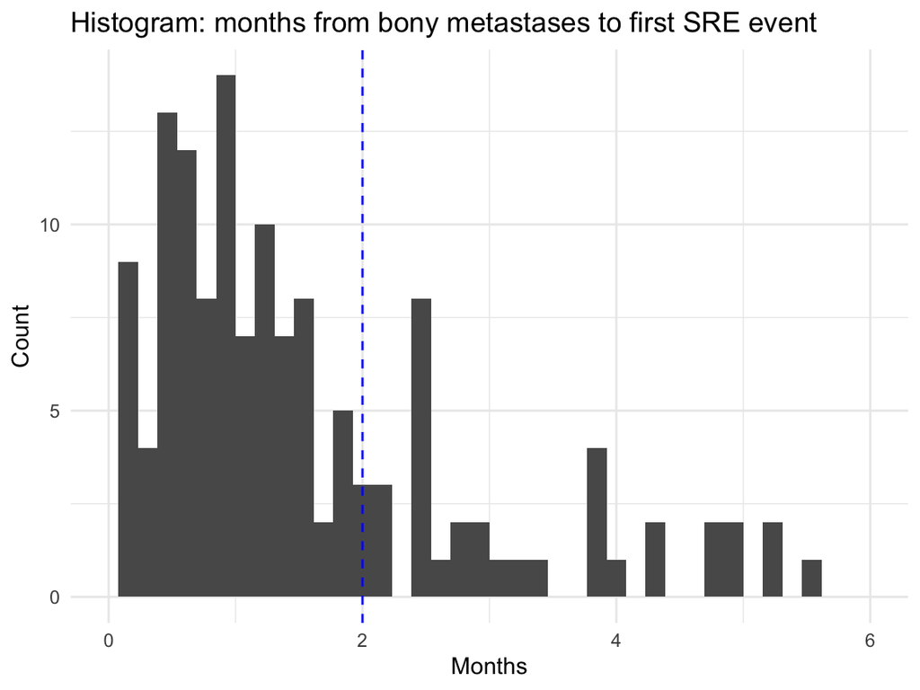

Since more than 60% patients developed SRE within 2 months, so we use developing SRE within 2 months to represent the risk of SRE.

### Association between age at diagnosis of bladder cancer and SRE development.

We compared the mean age at diagnosis of bladder cancer within the two cohorts mentioned above.

The null hypothesis is: There is no association between age at diagnosis of bladder cancer with developed an SRE within the first 2 months. And the alternative hypothesis is: There is an association between age at diagnosis of bladder cancer with developed an SRE within the first 2 months. p value is 0.0316, 95% CI of true difference in means is ( -6.0386 , -0.2827 ).

### Association between type of urinary diversion and SRE development.

The null hypothesis is: There is no association between type of urinary diversion and SRE development. And the alternative hypothesis is there is an association between type of urinary diversion and SRE development. First we use chi-square’s test to compute the expected value of the obtained contigency table, we found that none of the expected counts in this table less than 5, so Chi-square Test is appropriate for this situation. Therefore, we use Chi-square Test to test the dependency Type of urinary diversion and SRE development.

### Association between disease stage at diagnosis of bladder cancer and SRE development.

The null hypothesis is that there is no association between disease stage at diagnosis of bladder cancer and SRE development. And the alternative hypothesis is that there is an association between disease stage at diagnosis of bladder cancer and SRE development. First we use chi-square’s test to compute the expected value of the obtained contigency table, we found that some of the expected counts in the table are small (<5), so we may choose fisher’s exact test to test the dependency between SRE and disease stage at diagnosis of bladder cancer.

### Association between type of metastasis at diagnosis of bladder cancer and SRE development.

The null hypothesis is that there is no association between type of metastasis at diagnosis of bladder cancer and SRE development. And the alternative hypothesis is that there is an association between type of metastasis at diagnosis of bladder cancer and SRE development. First we use chi-square’s test to compute the expected value of the obtained contigency table, we found that some of the expected counts in the table are small (<5), so we may choose fisher’s exact test to test the dependency between SRE and type of metastasis at diagnosis of bladder cancer.

## Results

### Descriptive data exploration

**Descriptive for different characteristics of patients**

| **Characteristic** | **No SRE in 2 months**, N = 69<sup>1</sup> | **SRE in 2 months**, N = 105<sup>1</sup> |
| --- | --- | --- |
| Type of urinary diversion |  |  |
| Continent | 18 (26%) | 21 (20%) |
| Incontinent | 14 (20%) | 46 (44%) |
| None | 37 (54%) | 38 (36%) |
| Disease stage at diagnosis of bladder cancer |  |  |
| Distant Mets | 12 (17%) | 7 (6.7%) |
| Localized UTUC | 3 (4.3%) | 6 (5.7%) |
| MIBC | 25 (36%) | 51 (49%) |
| NMIBC | 23 (33%) | 37 (35%) |
| Regional | 6 (8.7%) | 4 (3.8%) |
| Type of metastasis at diagnosis of bladder cancer |  |  |
| Distant LN | 6 (8.7%) | 7 (6.7%) |
| Osseous | 34 (49%) | 57 (54%) |
| Regional LN | 4 (5.8%) | 3 (2.9%) |
| Visceral & Osseous | 14 (20%) | 15 (14%) |
| Visceral, non-osseous | 11 (16%) | 23 (22%) |

<sup>1</sup> Count(proportion)

Summary of age that developing to SRE in two months

| Characteristics | mean | median | sd | var | min | max | IQR | Range |
| --- | --- | --- | --- | --- | --- | --- | --- | --- |
| Age | 66.914 | 68 | 10.186 | 103.752 | 32 | 90 | 60.00 to 74.00 | 32.00 to 90.00 |

Summary of age that not developing to SRE in two months

| Characteristics | mean | median | sd | var | min | max | IQR | Range |
| --- | --- | --- | --- | --- | --- | --- | --- | --- |
| Age | 63.754 | 66 | 8.851 | 78.335 | 46 | 86 | 57.00 to 69.00 | 46.00 to 86.00 |

### Tests results for variables of interests with development of SRE at 2 months

Table that showing the p-values for interested variables

|  | p-value |
| --- | --- |
| Age | 0.032 |
| Type of urinary diversion | 0.006 |
| Stage of Diagnosis | 0.101 |
| Type of metastasis at diagnosis of bladder cancer | 0.551 |

### Tests results for all variables with development of SRE versus time.

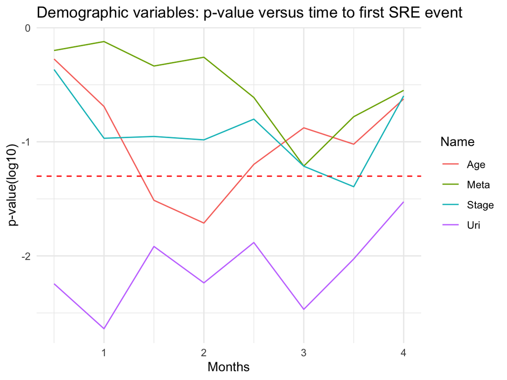

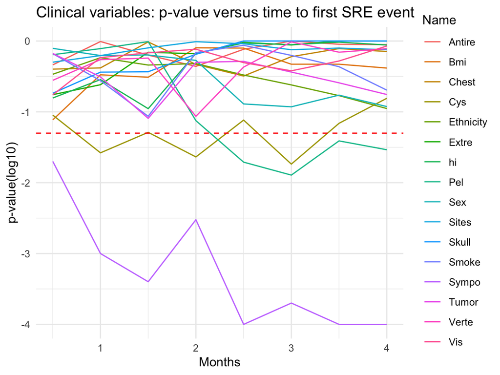

As we can see in the plot, the variables symptomatic and urinary diversion have the p value less than 0.05 at all threholds of months to get SRE between 0 to 4. However, for the values age, cystectomy, pelvis and diagnosis stage, they only have p-values less than 0.05 only in some thresholds of months of getting SRE. For example, the hypothesis test of Cystectomy and having SRE only has the p-values less than 0.05 in one, two and three months, but greater in four months. Which means, Cystectomy only relates to the diagnosis of SRE in one, two and three month, but does not affect the diagnosis of SRE within four months.

## Reference

Stellato M, Santini D, Cursano MC, Foderaro S, Tonini G, Procopio G. Bone metastases from urothelial carcinoma. The dark side of the moon. J Bone Oncol. 2021 Nov 28;31:100405. doi: 10.1016/j.jbo.2021.100405. PMID: 34934613; PMCID: PMC8661045.

So A, Chin J, Fleshner N, Saad F. Management of skeletal-related events in patients with advanced prostate cancer and bone metastases: Incorporating new agents into clinical practice. Can Urol Assoc J. 2012 Dec;6(6):465-70. doi: 10.5489/cuaj.12149. PMID: 23282666;PMCID: PMC3526633.

Chalasani V, Chin JL, Izawa JI. Histologic variants of urothelial bladder cancer and nonurothelial histology in bladder cancer. Can Urol Assoc J. 2009 Dec;3(6 Suppl 4):S193-8. doi: 10.5489/cuaj.1195. PMID: 20019984; PMCID: PMC2792446.

SEER Training Modules, Cancer Registration & Surveillance Modules. U. S. National Institutes of Health, National Cancer Institute. 05 December 2022 https://training.seer.cancer.gov/.

Chen S, Zhu S, Cui X, Xu W, Kong C, Zhang Z, Qian W. Identifying non-muscle-invasive and muscle-invasive bladder cancer based on blood serum surface-enhanced Raman spectroscopy. Biomed Opt Express. 2019 Jun 24;10(7):3533-3544. doi: 10.1364/BOE.10.003533. PMID: 31467792; PMCID: PMC6706043.

Cheung G, Sahai A, Billia M, Dasgupta P, Khan MS. Recent advances in the diagnosis and treatment of bladder cancer. BMC Med. 2013 Jan 17;11:13. doi: 10.1186/1741-7015-11-13. PMID: 23327481; PMCID: PMC3566975.